# Time Series Homework: Chapter 3 Lesson 3

Tristan Farrow

**Revision**

I changed the code to more align with the answer key and updated my responses to the questions. I also finished the last question.

## Data

```r
df <- rio::import("https://byuistats.github.io/timeseries/data/ILLNESS_CDCWONDER.csv") |>
  filter(`ICD Sub-Chapter Code` == "X60-X84")|>
  mutate(yearmonth = yearmonth(Date))

df2 <- read_csv("https://byuistats.github.io/timeseries/data/POPTHM.csv") |>
  mutate(yearmonth = yearmonth(observation_date))

illness <- df |> left_join(df2, by="yearmonth") |>
  mutate(`Deaths per 100000` = (Deaths/POPTHM)*100000) |>
  select(-c(observation_date)) |>
  filter(Year <= 2019)
```

## A Note Before Starting, Please Read

The data we will be looking at today covers a topic of deaths due to self harm. This is a incredibly serious and heavy topic and we would be remissed to not include some message at the beginning of this. People struggle with self harm and suicide due to a variety of different reasons. It is important to remember the following teachings and doctrines of the Church of Jesus Christ of Latter-Day Saints when approaching this topic:

- Mortal life is a precious gift that should be valued and protected (see D&C 18:10)
- When someone takes their own life, only God is able to judge their thoughts, their actions and their level of accountability. Suicide need not be the defining characteristic of an individual’s eternal life (see 1 Samuel 16:7)
- Through His Atonement, Jesus Christ experienced the fullness of mortal challenges so He could know “how to succor his people according to their infirmities” (Alma 7:11-13)

If you are struggling with thoughts of suicide or self harm, please know this. The world is better with you in it. We love you and want you to be here, and God loves you with an eternal love. You are not the only person who has struggled with this and there is hope and healing ahead. Please reach out to the Lord, those you trust, and the suicide prevention hotline (found by calling 988). Click [here](https://www.byui.edu/counseling-center/emergency-contact) for additional resources from BYU-Idaho.

If you know of someone who is struggling, [here](https://www.byui.edu/human-resources/0000018d-9fb8-dfac-afad-9ff9fb6d0000) is a good video with advice. As well the Church has additional resources that can be found in Gospel Library by going to the Life Help section under suicide.

## Questions

### Question 1 - Context and Measurement (10 points)

The first part of any time series analysis is context. You cannot properly analyze data without knowing what the data is measuring. Without context, the most simple features of data can be obscure and inscrutable. This homework assignment will center around the series below.

Please research the time series. In the spaces below, give the data collection process, unit of analysis, and meaning of each observation for the series.

#### **US Self Harm**

[CDC Website](https://wonder.cdc.gov/wonder/help/ucd.html#)

**Answer**

Data Collection: This data is derived from death certificates filed in the 50 U.S. states and District of Columbia. States code the death certificates and provide them to the National Center for Health Statistics (NCHS) through state registration or via direct copies. The cause of death is defined under the World Health Organization (WHO) definition: “the disease or injury which initiated the train of events leading directly to death, or the circumstances of the acciedent or violence which preceded the fatal injury.”

Unit of Analysis: The unit of analysis is the number of deaths from a cause.

Meaning of Observation: Each observation is an aggregation of the number of deaths from a cause at a given period of time.

### Question 2 - Additive Holt-Winters Forecasting (30 points)

This series imported above has not been seasonally adjusted.

##### a) Please use the Holt-Winters smoothing method to the series.

**Answer**

```r
illness_ts <- illness |>
  as_tsibble()
```

```
Using `yearmonth` as index variable.
```

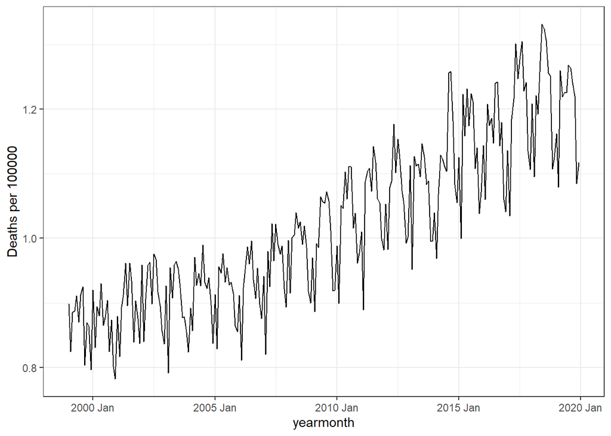

```r
ggplot(illness_ts, aes(x = yearmonth, y = `Deaths per 100000`)) +
  geom_line() +
  theme_bw()
```

```r
illness_hw <- illness_ts |>
  model(Additive = ETS(`Deaths per 100000` ~
                         trend("A", alpha = 0.15, beta = 0.0005) +
                         error("A") +
                         season("A", gamma = 0.01),
                       opt_crit = "amse", nmse = 1
                         ))
report(illness_hw)
```

```
Series: Deaths per 100000
Model: ETS(A,A,A)
  Smoothing parameters:
    alpha = 0.15
    beta  = 5e-04
    gamma = 0.01

  Initial states:
      l[0]        b[0]       s[0]       s[-1]       s[-2]       s[-3]
 0.8666982 0.001234788 -0.0845776 -0.06966815 0.004277882 0.003174214
      s[-4]      s[-5]      s[-6]     s[-7]      s[-8]      s[-9]      s[-10]
 0.05430962 0.06115529 0.02480376 0.0641101 0.02041718 0.02510358 -0.09877403
       s[-11]
 -0.004331844

  sigma^2:  0.0011

      AIC      AICc       BIC
-321.7869 -320.0147 -272.3749
```

##### b) What parameters values did you choose for $\alpha$, $\beta$, and $\gamma$. Justify your choice.

**Answer**

Alpha - 0.15 A small alpha was used to smooth out short-term fluctuations and give weight to larger trends. Beta - 0.0005 A small beta was used on the basis that mortality rate is expected to be consistent and change gradually over time. Gamma - 0.01 The small gamma was used as seasonal patterns are consistent and evolve slowly.

##### c) Please plot the Holt-Winters forecast of the series for the next 24 months superimposed against the original series. Please see [Figure 7](https://byuistats.github.io/timeseries/chapter_3_lesson_4.html#fig-crime-hw-forecast) in Chapter 3: Lesson 3

**Answer**

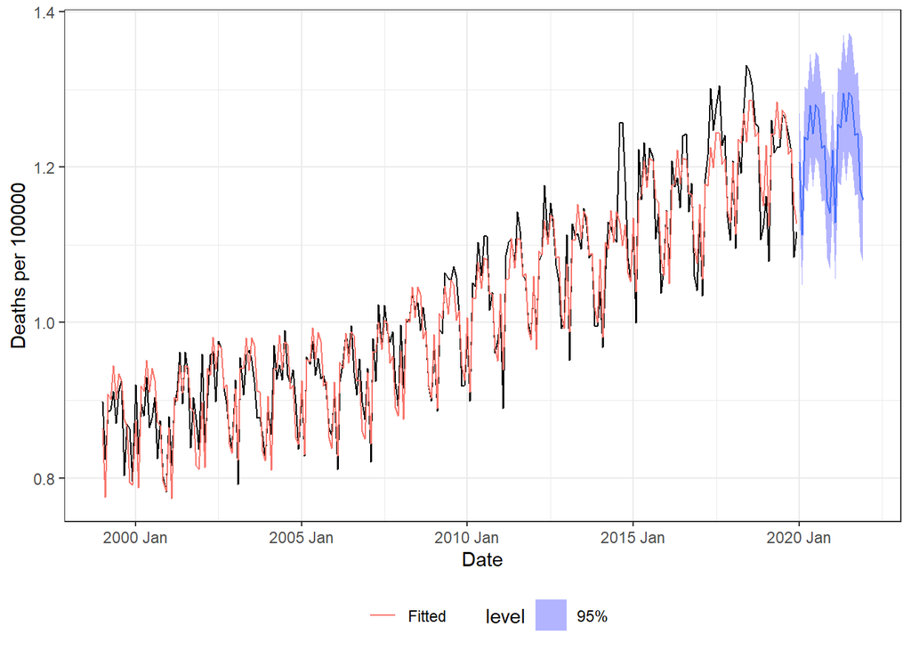

```r
library(forecast)
illness_hw |>
  forecast(h = "24 months") |>
  autoplot(illness_ts, level = 95) +
  geom_line(aes(y = .fitted, color = "Fitted"),
            data = augment(illness_hw)) +
  scale_color_discrete(name = "") +
  theme_bw() +
  labs(x = "Date") +
  theme(legend.position = "bottom")
```

### Question 3 - Additive Holt-Winters Forecasting: Evaluation (20 points)

##### a) The data has been filtered to stop around 2019. Below we have the complete series, please don’t look at it until you have reached this point in the homework. Compare your forecasting work with with the actual realization of the series. What lessons about forecasting can you learn from the occurrence of [Gray Rhino](https://chatgpt.com/share/6712c9e5-4f58-8005-888d-acae9895bd05) events like a pandemic?

**Answer**

```r
illness_curent <- df |> left_join(df2, by="yearmonth") |>
  mutate(`Deaths per 100000` = (Deaths/POPTHM)*100000) |>
  select(-c(observation_date))

forecast_data <- illness_hw |>
  forecast(h = "24 months")

illness_curent_ts <- illness_curent |>
  as_tsibble()
```

```
Using `yearmonth` as index variable.
```

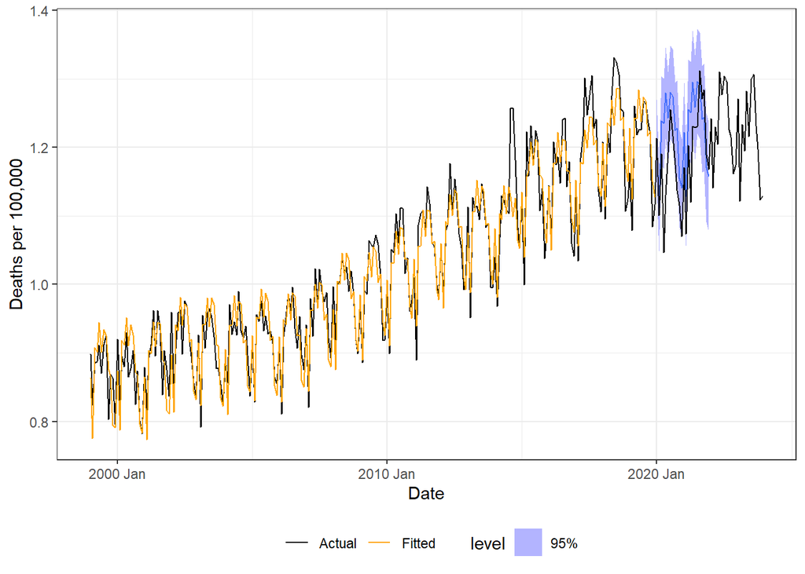

```r
autoplot(forecast_data, illness_ts, level = 95) +
  geom_line(data = illness_curent_ts,
            aes(x = yearmonth, y = `Deaths per 100000`, color = "Actual")) +
  geom_line(aes(y = .fitted, color = "Fitted"),
            data = augment(illness_hw)) +
  scale_color_manual(values = c("Fitted" = "orange", "Actual" = "black")) +
  labs(x = "Date", y = "Deaths per 100,000", color = "") +
  theme_bw() +
  theme(legend.position = "bottom")
```

The forecast estimated higher peaks than the actual result. A gray rhino is a highly probable, high impact event that is often ignored unitl it occurs like the pandemic. Since the model relies on continuity and historical patterns and would not be able to predict a sudden or abrupt event. Forecasting is probabilistic and not absolute and needs to be kept in the context of the data.

### Rubric

[output not shown]